# 06-Exercices-GARCH-VaR

Author

Romain CAPLIEZ

# Exercice 1 : Modéliser le risque du CAC40

Données à partir de la base Yahoo Finance : fonction `pdfetch::pdfetch_YAHOO()`.

Vous avez pour mission de modéliser le risque présent sur le marché du CAC40.

## Question 0

*Importer le setup de l’analyse.*

## Question 1

*Importer les données du CAC40 à partir de la base Yahoo Finance.*

## Question 2

*Les données de cours boursier du CAC40 sont-elles stationnaires ?*

## Question 3

*Stationnariser la série si besoin*

## Question 4

*Modéliser le risque à partir d’une mesure de Value at Risk non-conditionnelle historique, de Student (normale pour une version plus simple) en statique et en fenêtre glissante de 252 jours. Commentez.*

## Question 5

*Trouver le meilleur modèle (S)ARIMA pour modéliser l’espérance conditionnelle de la série stationnaire à partir du critère d’information BIC*

## Question 6

*Les résidus de ce modèle sont-ils normaux ? Sont-ils auto-corrélés ? Les résidus au carré sont-ils auto-corrélés ? Y a-t-il des effets ARCH dans les résidus. Qu’en concluez-vous pour la suite de l’analyse.*

## Question 7

*Estimer la volatilité conditionnelle à partir de 3 modèles (minimum) différents. Expliquez votre processus de sélection et de validation des modèles utilisés.*

## Question 8

*Calculer la VaR associée à ces 3 modèles.*

## Question 9

*Effectuer les tests de Backtests sur tous les modèles de VaR estimés. Quelles sont les conclusions ?*

## Question 10

*Parmi tous les modèles de VaR validés (ou parmi tous les modèles s’il n’y a pas assez de modèles validés) quel est le modèle que vous choisissez pour modéliser le risque du CAC40 ?*

# Exercice 2 : Prédire le FTSE100

*Votre patron vous demande de prédire les futurs rendements du FTSE100 ainsi que les risques de perte maximum pour un niveau de confiance de 99%. Expliquer votre démarche et abalyser les résultats.*

# Exercice 3 : LVMH

*Votre collège part à la retraite et vous transmet le projet sur lequel il travaillait : modéliser le risque des prix de l’action LVMH. Commentez les résultats et les méthodes qu’il utilise.*

```r
rm(list = ls())
source(here::here("02-codes", "utils", "setup.R"))
```

```r
lvmh <-
  pdfetch::pdfetch_YAHOO(
    "MC.PA",
    fields = "adjclose",
    from = as.Date("2008-01-03"),
    to = as.Date("2026-03-27")
  )
```

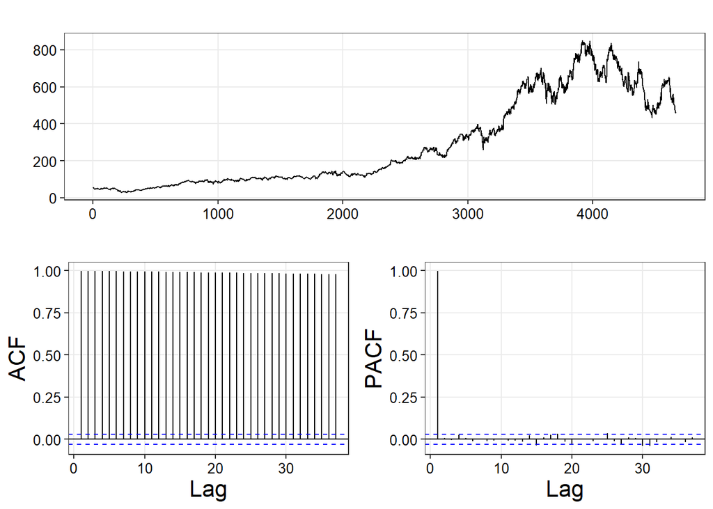

```r
forecast::ggtsdisplay(lvmh, point = FALSE)
```

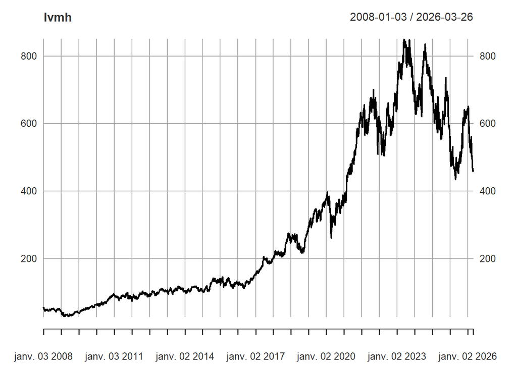

```r
plot(lvmh)
```

```r
urca::ur.df(lvmh, "trend", lags = 20, selectlags = "AIC") |> summary()
```

```
###############################################
# Augmented Dickey-Fuller Test Unit Root Test #
###############################################

Test regression trend


Call:
lm(formula = z.diff ~ z.lag.1 + 1 + tt + z.diff.lag)

Residuals:
    Min      1Q  Median      3Q     Max
-46.415  -1.581  -0.043   1.628  83.432

Coefficients:
               Estimate Std. Error t value Pr(>|t|)
(Intercept)  -0.0069552  0.2142287  -0.032  0.97410
z.lag.1      -0.0016869  0.0009619  -1.754  0.07955 .
tt            0.0002516  0.0001712   1.470  0.14173
z.diff.lag1  -0.0154563  0.0146999  -1.051  0.29310
z.diff.lag2   0.0103342  0.0146878   0.704  0.48173
z.diff.lag3  -0.0393154  0.0146881  -2.677  0.00746 **
z.diff.lag4  -0.0074513  0.0146900  -0.507  0.61201
z.diff.lag5   0.0134215  0.0146851   0.914  0.36079
z.diff.lag6  -0.0062564  0.0146876  -0.426  0.67016
z.diff.lag7   0.0103927  0.0146877   0.708  0.47924
z.diff.lag8   0.0043109  0.0146892   0.293  0.76917
z.diff.lag9   0.0074862  0.0146896   0.510  0.61034
z.diff.lag10 -0.0079604  0.0147054  -0.541  0.58831
z.diff.lag11  0.0106391  0.0147066   0.723  0.46946
z.diff.lag12  0.0121688  0.0147075   0.827  0.40806
z.diff.lag13 -0.0250169  0.0147090  -1.701  0.08905 .
z.diff.lag14  0.0423764  0.0147134   2.880  0.00399 **
z.diff.lag15 -0.0126623  0.0147144  -0.861  0.38954
z.diff.lag16 -0.0415920  0.0147152  -2.826  0.00473 **
z.diff.lag17 -0.0400166  0.0147267  -2.717  0.00661 **
---
Signif. codes:  0 '***' 0.001 '**' 0.01 '*' 0.05 '.' 0.1 ' ' 1

Residual standard error: 6.622 on 4624 degrees of freedom
Multiple R-squared:  0.00938,   Adjusted R-squared:  0.005309
F-statistic: 2.304 on 19 and 4624 DF,  p-value: 0.001053


Value of test-statistic is: -1.7537 1.388 1.5773

Critical values for test statistics:
      1pct  5pct 10pct
tau3 -3.96 -3.41 -3.12
phi2  6.09  4.68  4.03
phi3  8.27  6.25  5.34
```

```r
urca::ur.df(lvmh, "drift", lags = 20, selectlags = "AIC") |> summary()
```

```
###############################################
# Augmented Dickey-Fuller Test Unit Root Test #
###############################################

Test regression drift


Call:
lm(formula = z.diff ~ z.lag.1 + 1 + z.diff.lag)

Residuals:
    Min      1Q  Median      3Q     Max
-46.265  -1.577  -0.065   1.659  83.381

Coefficients:
               Estimate Std. Error t value Pr(>|t|)
(Intercept)   0.2145522  0.1522562   1.409  0.15886
z.lag.1      -0.0004062  0.0004073  -0.997  0.31869
z.diff.lag1  -0.0162387  0.0146921  -1.105  0.26910
z.diff.lag2   0.0095839  0.0146808   0.653  0.51390
z.diff.lag3  -0.0400535  0.0146813  -2.728  0.00639 **
z.diff.lag4  -0.0082081  0.0146828  -0.559  0.57617
z.diff.lag5   0.0126890  0.0146784   0.864  0.38738
z.diff.lag6  -0.0069929  0.0146809  -0.476  0.63387
z.diff.lag7   0.0096639  0.0146812   0.658  0.51041
z.diff.lag8   0.0035924  0.0146829   0.245  0.80673
z.diff.lag9   0.0067599  0.0146831   0.460  0.64526
z.diff.lag10 -0.0086568  0.0146996  -0.589  0.55595
z.diff.lag11  0.0099527  0.0147010   0.677  0.49844
z.diff.lag12  0.0114886  0.0147021   0.781  0.43459
z.diff.lag13 -0.0257160  0.0147032  -1.749  0.08036 .
z.diff.lag14  0.0417034  0.0147081   2.835  0.00460 **
z.diff.lag15 -0.0133223  0.0147094  -0.906  0.36514
z.diff.lag16 -0.0422468  0.0147103  -2.872  0.00410 **
z.diff.lag17 -0.0406475  0.0147223  -2.761  0.00579 **
---
Signif. codes:  0 '***' 0.001 '**' 0.01 '*' 0.05 '.' 0.1 ' ' 1

Residual standard error: 6.623 on 4625 degrees of freedom
Multiple R-squared:  0.008917,  Adjusted R-squared:  0.00506
F-statistic: 2.312 on 18 and 4625 DF,  p-value: 0.001299


Value of test-statistic is: -0.9973 1.0019

Critical values for test statistics:
      1pct  5pct 10pct
tau2 -3.43 -2.86 -2.57
phi1  6.43  4.59  3.78
```

```r
urca::ur.df(lvmh, "none", lags = 20, selectlags = "AIC") |> summary()
```

```
###############################################
# Augmented Dickey-Fuller Test Unit Root Test #
###############################################

Test regression none


Call:
lm(formula = z.diff ~ z.lag.1 - 1 + z.diff.lag)

Residuals:
    Min      1Q  Median      3Q     Max
-46.310  -1.453   0.080   1.786  83.306

Coefficients:
                Estimate  Std. Error t value Pr(>|t|)
z.lag.1       0.00003509  0.00026050   0.135  0.89284
z.diff.lag1  -0.01625228  0.01469361  -1.106  0.26875
z.diff.lag2   0.00957592  0.01468237   0.652  0.51430
z.diff.lag3  -0.04006456  0.01468290  -2.729  0.00638 **
z.diff.lag4  -0.00820225  0.01468438  -0.559  0.57648
z.diff.lag5   0.01269758  0.01468000   0.865  0.38711
z.diff.lag6  -0.00698518  0.01468245  -0.476  0.63427
z.diff.lag7   0.00967311  0.01468272   0.659  0.51005
z.diff.lag8   0.00359892  0.01468450   0.245  0.80640
z.diff.lag9   0.00676191  0.01468465   0.460  0.64520
z.diff.lag10 -0.00865646  0.01470120  -0.589  0.55601
z.diff.lag11  0.00995664  0.01470260   0.677  0.49831
z.diff.lag12  0.01148835  0.01470364   0.781  0.43465
z.diff.lag13 -0.02572320  0.01470475  -1.749  0.08030 .
z.diff.lag14  0.04170735  0.01470964   2.835  0.00460 **
z.diff.lag15 -0.01333822  0.01471095  -0.907  0.36462
z.diff.lag16 -0.04225736  0.01471184  -2.872  0.00409 **
z.diff.lag17 -0.04064281  0.01472388  -2.760  0.00580 **
---
Signif. codes:  0 '***' 0.001 '**' 0.01 '*' 0.05 '.' 0.1 ' ' 1

Residual standard error: 6.623 on 4626 degrees of freedom
Multiple R-squared:  0.008667,  Adjusted R-squared:  0.00481
F-statistic: 2.247 on 18 and 4626 DF,  p-value: 0.001876


Value of test-statistic is: 0.1347

Critical values for test statistics:
      1pct  5pct 10pct
tau1 -2.58 -1.95 -1.62
```

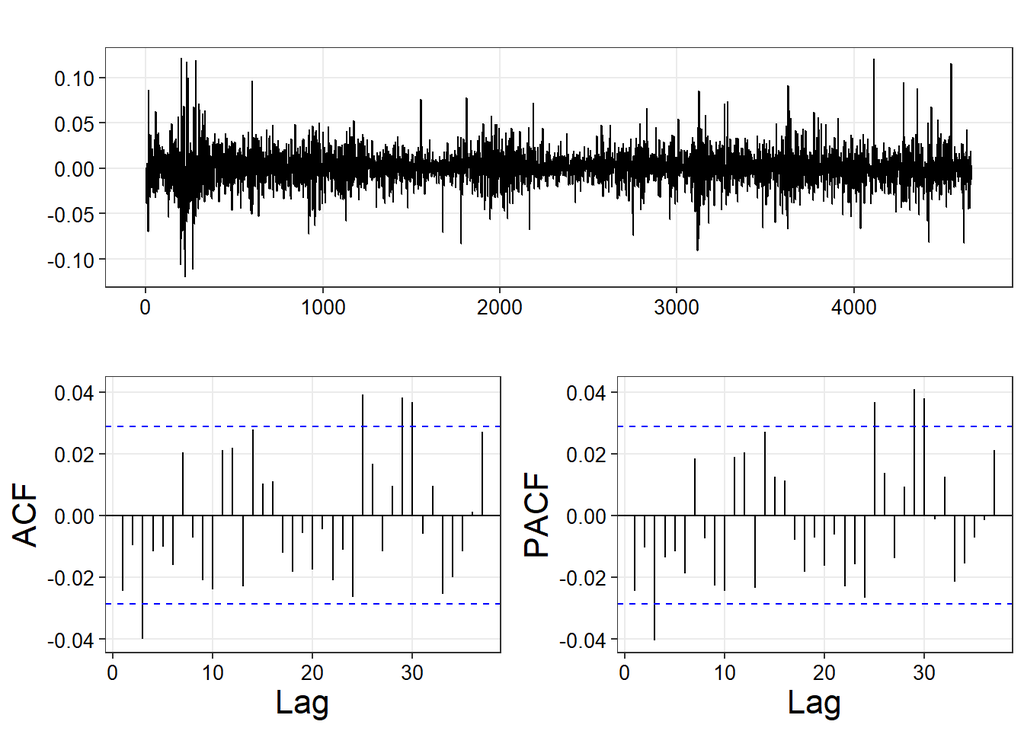

```r
rend_lvmh <-
  log(lvmh) - log(lag(lvmh)) |>
  na.omit()

forecast::ggtsdisplay(rend_lvmh, point = FALSE)
```

```r
moments::jarque.test(as.numeric(rend_lvmh))
```

```
    Jarque-Bera Normality Test

data:  as.numeric(rend_lvmh)
JB = 4287, p-value < 0.00000000000000022
alternative hypothesis: greater
```

```r
t_couv <- 0.01
```

```r
VaR_VCov <- (-(mean(rend_lvmh)+sd(rend_lvmh)*qnorm(t_couv))) |> print()
```

```
[1] 0.04291615
```

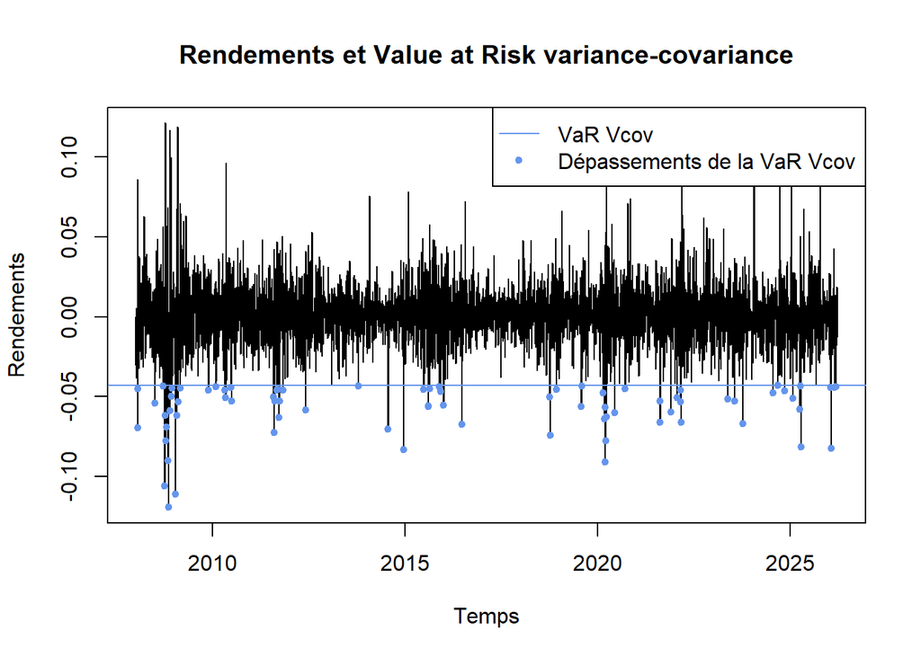

```r
plot(as.zoo(rend_lvmh),
      main = "Rendements et Value at Risk variance-covariance",
      xlab = "Temps",
      ylab = "Rendements")
  abline(h= -VaR_VCov, col="cornflowerblue")
  points(as.zoo(rend_lvmh[as.numeric(rend_lvmh) < -VaR_VCov]), pch=20, col="cornflowerblue")
  legend("topright", legend = c("VaR Vcov","Dépassements de la VaR Vcov"),
         pch = c(NA,20), lty = c(1, NA), col = "cornflowerblue")
```

```r
K <- kurtosis(rend_lvmh)
S <- skewness(rend_lvmh)

k <- as.numeric(qnorm(t_couv)+(qnorm(t_couv)^2-1)*(S/6)+(qnorm(t_couv)^3-3*qnorm(t_couv))*(K/24)+(2*qnorm(t_couv)^3-5*qnorm(t_couv))*(S^2/36))

VaR_CFisher<- as.numeric(-(mean(rend_lvmh)+sd(rend_lvmh)*k)) |> print()
```

```
[1] 0.07455509
```

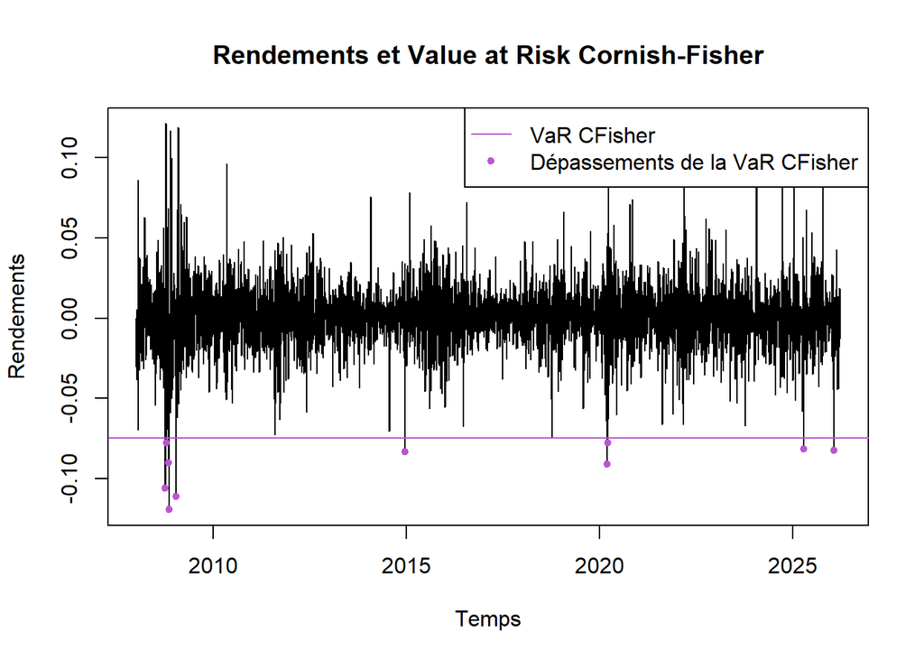

```r
plot(as.zoo(rend_lvmh),
      main = "Rendements et Value at Risk Cornish-Fisher",
      xlab = "Temps",
      ylab = "Rendements")
  abline(h= -VaR_CFisher, col="mediumorchid")
  points(as.zoo(rend_lvmh[as.numeric(rend_lvmh) < -VaR_CFisher]), pch=20, col="mediumorchid")
  legend("topright", legend = c("VaR CFisher","Dépassements de la VaR CFisher"),
         pch = c(NA,20), lty = c(1, NA), col = "mediumorchid")
```

```r
param.sd <- fitdist(distribution = 'std', x = rend_lvmh)$pars
quantile.sd <- qt(t_couv, df=param.sd["shape"])

VaR_student <- (-mean(rend_lvmh)-sd(rend_lvmh)*quantile.sd*sqrt((quantile.sd-2)/quantile.sd)) |> print()
```

```
[1] 0.0885578
```

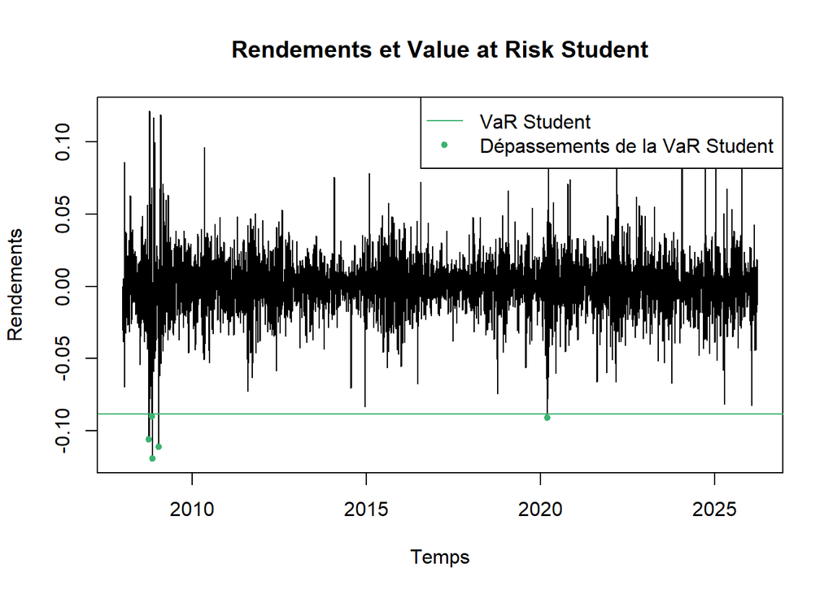

```r
plot(as.zoo(rend_lvmh),
      main = "Rendements et Value at Risk Student",
      xlab = "Temps",
      ylab = "Rendements")
  abline(h= -VaR_student, col="mediumseagreen")
  points(as.zoo(rend_lvmh[as.numeric(rend_lvmh) < -VaR_student]), pch=20, col="mediumseagreen")
  legend("topright", legend = c("VaR Student","Dépassements de la VaR Student"),
         pch = c(NA,20), lty = c(1, NA), col = "mediumseagreen")
```

```r
n_backtest <- 2000

taille_sample_estimation <- length(rend_lvmh) - n_backtest

sample_estimation <- rend_lvmh[1:taille_sample_estimation]

sample_backtest <- rend_lvmh[(taille_sample_estimation+1):length(rend_lvmh)]
```

```r
VaR_VCov_estimation <- (-(mean(sample_estimation)+sd(sample_estimation)*qnorm(t_couv)))

test_VaR_VCov <-
  rugarch::VaRTest(
    alpha = t_couv,
    actual = sample_backtest,
    VaR = rep(-VaR_VCov_estimation, times = length(sample_backtest)),
    conf.level = 0.95
  )

tibble(
  name = names(unlist(test_VaR_VCov)),
  value = unlist(test_VaR_VCov)
) |>
  print(n = 20)
```

```
# A tibble: 12 × 2
   name            value
   <chr>           <chr>
 1 expected.exceed 20
 2 actual.exceed   34
 3 uc.H0           Correct Exceedances
 4 uc.LRstat       8.18194510909123
 5 uc.critical     3.84145882069412
 6 uc.LRp          0.00423093684953424
 7 uc.Decision     Reject H0
 8 cc.H0           Correct Exceedances & Independent
 9 cc.LRstat       10.4255909694824
10 cc.critical     5.99146454710798
11 cc.LRp          0.00544642698307951
12 cc.Decision     Reject H0
```

```r
HIT_VCov <-
  if_else(sample_backtest < -VaR_VCov_estimation, 1, 0)

HIT_centre_VCov <- HIT_VCov - t_couv

stats::Box.test(HIT_centre_VCov, lag = 5, type = "Ljung-Box")
```

```
    Box-Ljung test

data:  HIT_centre_VCov
X-squared = 28.608, df = 5, p-value = 0.00002767
```

```r
df <- tibble(
  HIT_centre = HIT_centre_VCov,
  rend = sample_backtest |> as.numeric(),
  rend2 = sample_backtest**2 |> as.numeric()
)

ARDL::ardl(
  HIT_centre ~ rend + rend2,
  data = df,
  order = 5
) |>
  summary()
```

```
Time series regression with "ts" data:
Start = 6, End = 2000

Call:
dynlm::dynlm(formula = full_formula, data = data, start = start,
    end = end)

Residuals:
     Min       1Q   Median       3Q      Max
-0.71827 -0.02552  0.00925  0.02990  0.73041

Coefficients:
                  Estimate Std. Error t value             Pr(>|t|)
(Intercept)      -0.018914   0.003056  -6.190       0.000000000731 ***
L(HIT_centre, 1)  0.003505   0.022494   0.156               0.8762
L(HIT_centre, 2) -0.016735   0.022497  -0.744               0.4571
L(HIT_centre, 3)  0.017929   0.022536   0.796               0.4264
L(HIT_centre, 4) -0.004361   0.022506  -0.194               0.8464
L(HIT_centre, 5)  0.004296   0.022482   0.191               0.8485
rend             -3.152928   0.120388 -26.190 < 0.0000000000000002 ***
L(rend, 1)       -0.185045   0.139890  -1.323               0.1861
L(rend, 2)       -0.317955   0.139848  -2.274               0.0231 *
L(rend, 3)        0.058905   0.140008   0.421               0.6740
L(rend, 4)        0.021289   0.140771   0.151               0.8798
L(rend, 5)       -0.024330   0.140435  -0.173               0.8625
rend2            76.422489   2.662759  28.700 < 0.0000000000000002 ***
L(rend2, 1)       0.211921   3.165889   0.067               0.9466
L(rend2, 2)       6.670528   3.144204   2.122               0.0340 *
L(rend2, 3)       0.909246   3.139156   0.290               0.7721
L(rend2, 4)      -2.119299   3.147435  -0.673               0.5008
L(rend2, 5)      -3.543890   3.145991  -1.126               0.2601
---
Signif. codes:  0 '***' 0.001 '**' 0.01 '*' 0.05 '.' 0.1 ' ' 1

Residual standard error: 0.09867 on 1977 degrees of freedom
Multiple R-squared:  0.4241,    Adjusted R-squared:  0.4192
F-statistic: 85.64 on 17 and 1977 DF,  p-value: < 0.00000000000000022
```

```r
K <- kurtosis(sample_estimation)
S <- skewness(sample_estimation)

k <- as.numeric(qnorm(t_couv)+(qnorm(t_couv)^2-1)*(S/6)+(qnorm(t_couv)^3-3*qnorm(t_couv))*(K/24)+(2*qnorm(t_couv)^3-5*qnorm(t_couv))*(S^2/36))

VaR_CFisher_estimation <- as.numeric(-(mean(sample_estimation)+sd(sample_estimation)*k))

test_VaR_CFisher <-
  rugarch::VaRTest(
    alpha = t_couv,
    actual = sample_backtest,
    VaR = rep(-VaR_CFisher_estimation, times = length(sample_backtest)),
    conf.level = 0.95
  )

tibble(
  name = names(unlist(test_VaR_CFisher)),
  value = unlist(test_VaR_CFisher)
) |>
  print(n = 20)
```

```
# A tibble: 12 × 2
   name            value
   <chr>           <chr>
 1 expected.exceed 20
 2 actual.exceed   4
 3 uc.H0           Correct Exceedances
 4 uc.LRstat       19.2534427663781
 5 uc.critical     3.84145882069412
 6 uc.LRp          0.0000114463780930274
 7 uc.Decision     Reject H0
 8 cc.H0           Correct Exceedances & Independent
 9 cc.LRstat       19.2694828773756
10 cc.critical     5.99146454710798
11 cc.LRp          0.0000654161466900893
12 cc.Decision     Reject H0
```

```r
HIT_CFisher <-
  if_else(sample_backtest < -VaR_CFisher_estimation, 1, 0)

HIT_centre_CFisher <- HIT_VCov - t_couv

stats::Box.test(HIT_centre_VCov, lag = 5, type = "Ljung-Box")
```

```
    Box-Ljung test

data:  HIT_centre_VCov
X-squared = 28.608, df = 5, p-value = 0.00002767
```

```r
df <- tibble(
  HIT_centre = HIT_centre_CFisher,
  rend = sample_backtest |> as.numeric(),
  rend2 = sample_backtest**2 |> as.numeric()
)

ARDL::ardl(
  HIT_centre ~ rend + rend2,
  data = df,
  order = 5
) |>
  summary()
```

```
Time series regression with "ts" data:
Start = 6, End = 2000

Call:
dynlm::dynlm(formula = full_formula, data = data, start = start,
    end = end)

Residuals:
     Min       1Q   Median       3Q      Max
-0.71827 -0.02552  0.00925  0.02990  0.73041

Coefficients:
                  Estimate Std. Error t value             Pr(>|t|)
(Intercept)      -0.018914   0.003056  -6.190       0.000000000731 ***
L(HIT_centre, 1)  0.003505   0.022494   0.156               0.8762
L(HIT_centre, 2) -0.016735   0.022497  -0.744               0.4571
L(HIT_centre, 3)  0.017929   0.022536   0.796               0.4264
L(HIT_centre, 4) -0.004361   0.022506  -0.194               0.8464
L(HIT_centre, 5)  0.004296   0.022482   0.191               0.8485
rend             -3.152928   0.120388 -26.190 < 0.0000000000000002 ***
L(rend, 1)       -0.185045   0.139890  -1.323               0.1861
L(rend, 2)       -0.317955   0.139848  -2.274               0.0231 *
L(rend, 3)        0.058905   0.140008   0.421               0.6740
L(rend, 4)        0.021289   0.140771   0.151               0.8798
L(rend, 5)       -0.024330   0.140435  -0.173               0.8625
rend2            76.422489   2.662759  28.700 < 0.0000000000000002 ***
L(rend2, 1)       0.211921   3.165889   0.067               0.9466
L(rend2, 2)       6.670528   3.144204   2.122               0.0340 *
L(rend2, 3)       0.909246   3.139156   0.290               0.7721
L(rend2, 4)      -2.119299   3.147435  -0.673               0.5008
L(rend2, 5)      -3.543890   3.145991  -1.126               0.2601
---
Signif. codes:  0 '***' 0.001 '**' 0.01 '*' 0.05 '.' 0.1 ' ' 1

Residual standard error: 0.09867 on 1977 degrees of freedom
Multiple R-squared:  0.4241,    Adjusted R-squared:  0.4192
F-statistic: 85.64 on 17 and 1977 DF,  p-value: < 0.00000000000000022
```

```r
param.sd <- fitdist(distribution = 'std', x = sample_estimation)$pars
quantile.sd <- qt(t_couv, df=param.sd["shape"])

VaR_student_estimation <- (-mean(sample_estimation)-sd(sample_estimation)*quantile.sd*sqrt((quantile.sd-2)/quantile.sd))

test_VaR_student <-
  rugarch::VaRTest(
    alpha = t_couv,
    actual = sample_backtest,
    VaR = rep(-VaR_student_estimation, times = length(sample_backtest)),
    conf.level = 0.95
  )

tibble(
  name = names(unlist(test_VaR_student)),
  value = unlist(test_VaR_student)
) |>
  print(n = 20)
```

```
# A tibble: 12 × 2
   name            value
   <chr>           <chr>
 1 expected.exceed 20
 2 actual.exceed   1
 3 uc.H0           Correct Exceedances
 4 uc.LRstat       32.1902782785452
 5 uc.critical     3.84145882069412
 6 uc.LRp          0.0000000139788461916979
 7 uc.Decision     Reject H0
 8 cc.H0           Correct Exceedances & Independent
 9 cc.LRstat       32.1912792795877
10 cc.critical     5.99146454710798
11 cc.LRp          0.000000102271004553955
12 cc.Decision     Reject H0
```

```r
HIT_student <-
  if_else(sample_backtest < -VaR_student_estimation, 1, 0)

HIT_centre_student <- HIT_VCov - t_couv

stats::Box.test(HIT_centre_student, lag = 5, type = "Ljung-Box")
```

```
    Box-Ljung test

data:  HIT_centre_student
X-squared = 28.608, df = 5, p-value = 0.00002767
```

```r
df <- tibble(
  HIT_centre = HIT_centre_student,
  rend = sample_backtest |> as.numeric(),
  rend2 = sample_backtest**2 |> as.numeric()
)

ARDL::ardl(
  HIT_centre ~ rend + rend2,
  data = df,
  order = 5
) |>
  summary()
```

```
Time series regression with "ts" data:
Start = 6, End = 2000

Call:
dynlm::dynlm(formula = full_formula, data = data, start = start,
    end = end)

Residuals:
     Min       1Q   Median       3Q      Max
-0.71827 -0.02552  0.00925  0.02990  0.73041

Coefficients:
                  Estimate Std. Error t value             Pr(>|t|)
(Intercept)      -0.018914   0.003056  -6.190       0.000000000731 ***
L(HIT_centre, 1)  0.003505   0.022494   0.156               0.8762
L(HIT_centre, 2) -0.016735   0.022497  -0.744               0.4571
L(HIT_centre, 3)  0.017929   0.022536   0.796               0.4264
L(HIT_centre, 4) -0.004361   0.022506  -0.194               0.8464
L(HIT_centre, 5)  0.004296   0.022482   0.191               0.8485
rend             -3.152928   0.120388 -26.190 < 0.0000000000000002 ***
L(rend, 1)       -0.185045   0.139890  -1.323               0.1861
L(rend, 2)       -0.317955   0.139848  -2.274               0.0231 *
L(rend, 3)        0.058905   0.140008   0.421               0.6740
L(rend, 4)        0.021289   0.140771   0.151               0.8798
L(rend, 5)       -0.024330   0.140435  -0.173               0.8625
rend2            76.422489   2.662759  28.700 < 0.0000000000000002 ***
L(rend2, 1)       0.211921   3.165889   0.067               0.9466
L(rend2, 2)       6.670528   3.144204   2.122               0.0340 *
L(rend2, 3)       0.909246   3.139156   0.290               0.7721
L(rend2, 4)      -2.119299   3.147435  -0.673               0.5008
L(rend2, 5)      -3.543890   3.145991  -1.126               0.2601
---
Signif. codes:  0 '***' 0.001 '**' 0.01 '*' 0.05 '.' 0.1 ' ' 1

Residual standard error: 0.09867 on 1977 degrees of freedom
Multiple R-squared:  0.4241,    Adjusted R-squared:  0.4192
F-statistic: 85.64 on 17 and 1977 DF,  p-value: < 0.00000000000000022
```

```r
best_arma <- forecast::auto.arima(rend_lvmh)

ar <- best_arma$arma[1]
ma <- ar <- best_arma$arma[2]

best_arma$arma[c(1,6,2)] |>  print()
```

```
[1] 1 0 2
```

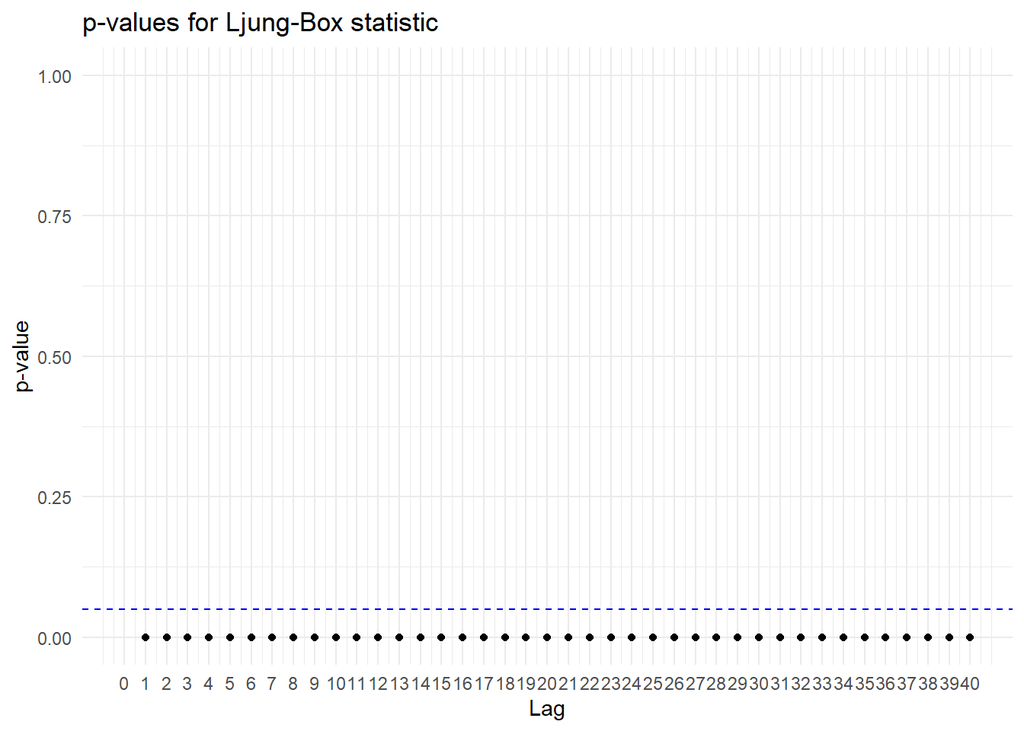

```r
LSTS::Box.Ljung.Test(best_arma$residuals**2, lag = 40)
```

```r
fDMA::archtest(as.numeric(best_arma$residuals**2), lag = 20)
```

```
    Engle's LM ARCH Test

data:  as.numeric(best_arma$residuals^2)
statistic = 213.21, lag = 20, p-value < 0.00000000000000022
alternative hypothesis: ARCH effects of order 20 are present
```

```r
garch11_spec <-
  rugarch::ugarchspec(
    variance.model =
      list(
        model = "sGARCH",
        garchOrder = c(1,1),
        variance.targeting = TRUE
      ),
    mean.model =
      list(
        armaOrder = c(ar,ma),
        include.mean = TRUE
      ),
    distribution.model = "sged"
  )

garch11_fit <-
  rugarch::ugarchfit(
    garch11_spec,
    rend_lvmh
  )

garch11_fit
```

```
*---------------------------------*
*          GARCH Model Fit        *
*---------------------------------*

Conditional Variance Dynamics
-----------------------------------
GARCH Model : sGARCH(1,1)
Mean Model  : ARFIMA(2,0,2)
Distribution    : sged

Optimal Parameters
------------------------------------
        Estimate  Std. Error  t value Pr(>|t|)
mu      0.000703    0.000225   3.1186 0.001817
ar1     0.067245    0.031190   2.1560 0.031086
ar2     0.411412    0.107076   3.8422 0.000122
ma1    -0.105169    0.027847  -3.7766 0.000159
ma2    -0.430241    0.105626  -4.0733 0.000046
alpha1  0.052972    0.003327  15.9199 0.000000
beta1   0.930333    0.001486 626.1829 0.000000
skew    0.986798    0.019479  50.6591 0.000000
shape   1.227266    0.031485  38.9788 0.000000
omega   0.000006          NA       NA       NA

Robust Standard Errors:
        Estimate  Std. Error  t value Pr(>|t|)
mu      0.000703    0.000261   2.6918 0.007107
ar1     0.067245    0.028793   2.3355 0.019519
ar2     0.411412    0.258901   1.5891 0.112044
ma1    -0.105169    0.012428  -8.4623 0.000000
ma2    -0.430241    0.255252  -1.6856 0.091882
alpha1  0.052972    0.007090   7.4711 0.000000
beta1   0.930333    0.002765 336.4706 0.000000
skew    0.986798    0.024541  40.2095 0.000000
shape   1.227266    0.041826  29.3419 0.000000
omega   0.000006          NA       NA       NA

LogLikelihood : 12447.91

Information Criteria
```

[output cut: 53 more lines]

```
Negative Sign Bias   1.599 0.109920
Positive Sign Bias   2.699 0.006981 ***
Joint Effect        10.505 0.014729  **


Adjusted Pearson Goodness-of-Fit Test:
------------------------------------
  group statistic p-value(g-1)
1    20     33.19      0.02287
2    30     33.08      0.27436
3    40     47.75      0.15883
4    50     60.57      0.12426


Elapsed time : 2.516509
```

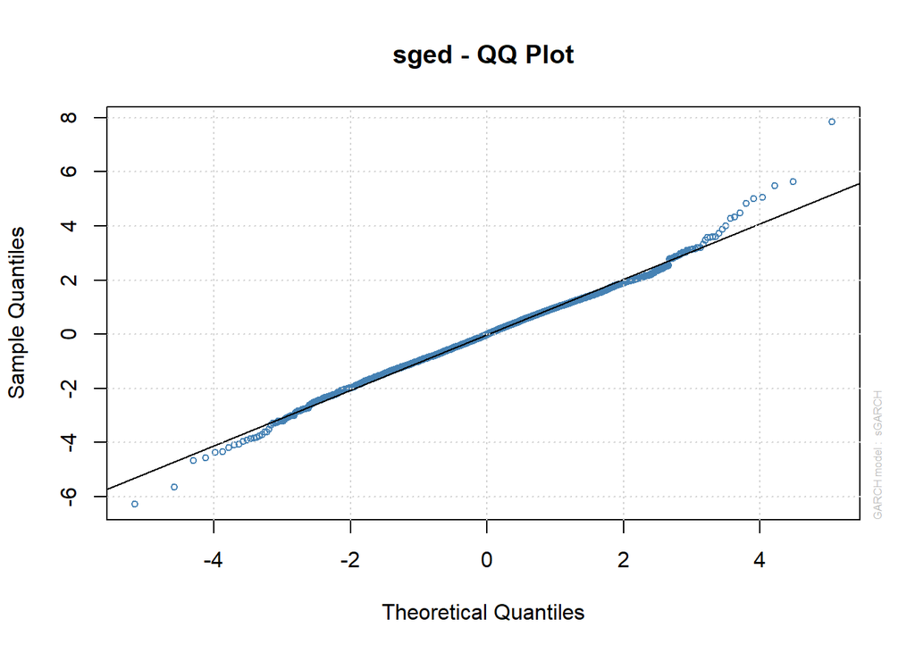

```r
plot(garch11_fit, which = 9)
```

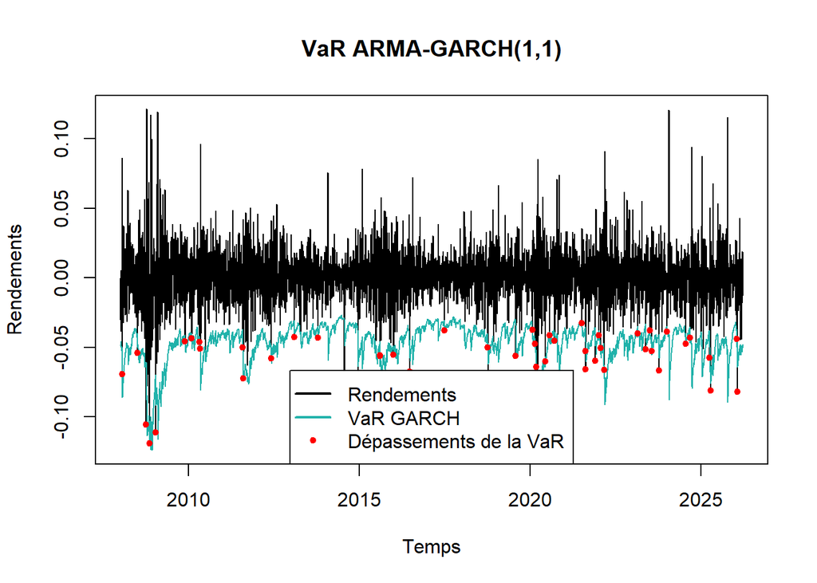

```r
# Calculer la VaR à partir du modèle EGARCH
VaR_GARCH <- -(as.numeric(quantile(garch11_fit, probs = t_couv)))

# Représenter les rendements et la VaR
plot(
  # Combiner dans un seul df les rendements et la VaR
  as.zoo(cbind(rend_lvmh,-VaR_GARCH)),
  screens=1,
  col = c("black","lightseagreen"),
  main="VaR ARMA-GARCH(1,1)",
  xlab = "Temps",
  ylab = "Rendements"
)
points(as.zoo(rend_lvmh[as.numeric(rend_lvmh) < -VaR_GARCH]), pch=20, col="red")
legend("bottom",c("Rendements","VaR GARCH", "Dépassements de la VaR"),
         col = c("black","lightseagreen", 'red'),lty = c(1,1,NA),lwd = c(2,2,NA),pch = c(NA,NA,20))
```

```r
garch11_estimation_fit <-
  rugarch::ugarchfit(
    garch11_spec,
    rend_lvmh,
    out.sample = n_backtest
  )

forecast_garch11 <-
  rugarch::ugarchforecast(
    garch11_estimation_fit,
    data = rend_lvmh,
    n.roll = n_backtest-1,
    n.ahead = 1
  )

VaR_GARCH_backtest <- -(as.numeric(quantile(forecast_garch11, probs = 0.01)))

test_VaR_GARCH<-
  rugarch::VaRTest(
    alpha = t_couv,
    actual = sample_backtest,
    VaR = -VaR_GARCH_backtest,
    conf.level = 0.95
  )

tibble(
  name = names(unlist(test_VaR_GARCH)),
  value = unlist(test_VaR_GARCH)
) |>
  print(n = 20)
```

```
# A tibble: 12 × 2
   name            value
   <chr>           <chr>
 1 expected.exceed 20
 2 actual.exceed   30
 3 uc.H0           Correct Exceedances
 4 uc.LRstat       4.37849677769573
 5 uc.critical     3.84145882069412
 6 uc.LRp          0.0363950816720029
 7 uc.Decision     Reject H0
 8 cc.H0           Correct Exceedances & Independent
 9 cc.LRstat       7.41028267304434
10 cc.critical     5.99146454710798
11 cc.LRp          0.0245967407041665
12 cc.Decision     Reject H0
```

```r
HIT <- if_else(sample_backtest < -VaR_GARCH_backtest, 1, 0)

HIT_centre <- HIT - 0.01

stats::Box.test(HIT_centre, lag = 5, type = "Ljung-Box")
```

```
    Box-Ljung test

data:  HIT_centre
X-squared = 7.8284, df = 5, p-value = 0.166
```

```r
df <-
  tibble(
    HIT_centre = HIT_centre,
    rend = sample_backtest,
    rend2 = sample_backtest**2
  )

ARDL::ardl(
  HIT_centre ~ rend + rend2,
  data = df,
  order = 5
) |>
  summary()
```

```
Time series regression with "ts" data:
Start = 6, End = 2000

Call:
dynlm::dynlm(formula = full_formula, data = data, start = start,
    end = end)

Residuals:
     Min       1Q   Median       3Q      Max
-0.58429 -0.02453  0.00551  0.02254  0.84485

Coefficients:
                  Estimate Std. Error t value             Pr(>|t|)
(Intercept)      -0.008767   0.002990  -2.932              0.00341 **
L(HIT_centre, 1)  0.009453   0.022519   0.420              0.67470
L(HIT_centre, 2) -0.028049   0.022499  -1.247              0.21268
L(HIT_centre, 3)  0.004019   0.022500   0.179              0.85825
L(HIT_centre, 4) -0.003649   0.022482  -0.162              0.87108
L(HIT_centre, 5)  0.006732   0.022462   0.300              0.76445
rend             -2.644753   0.123224 -21.463 < 0.0000000000000002 ***
L(rend, 1)       -0.187270   0.137030  -1.367              0.17190
L(rend, 2)       -0.202941   0.136924  -1.482              0.13846
L(rend, 3)       -0.176488   0.136651  -1.292              0.19667
L(rend, 4)        0.011665   0.137550   0.085              0.93242
L(rend, 5)        0.063204   0.137068   0.461              0.64477
rend2            62.710622   2.715540  23.093 < 0.0000000000000002 ***
L(rend2, 1)       0.657898   3.056801   0.215              0.82961
L(rend2, 2)      -5.265772   3.034858  -1.735              0.08288 .
L(rend2, 3)      -4.618045   3.029827  -1.524              0.12762
L(rend2, 4)      -5.419419   3.037485  -1.784              0.07455 .
L(rend2, 5)      -5.051500   3.041041  -1.661              0.09685 .
---
Signif. codes:  0 '***' 0.001 '**' 0.01 '*' 0.05 '.' 0.1 ' ' 1

Residual standard error: 0.1007 on 1977 degrees of freedom
Multiple R-squared:  0.3218,    Adjusted R-squared:  0.3159
F-statistic: 55.17 on 17 and 1977 DF,  p-value: < 0.00000000000000022
```

```r
egarch11_spec <-
  rugarch::ugarchspec(
    variance.model =
      list(
        model = "eGARCH",
        garchOrder = c(1,1),
        variance.targeting = TRUE
      ),
    mean.model =
      list(
        armaOrder = c(ar,ma),
        include.mean = TRUE
      ),
    distribution.model = "sged"
  )

egarch11_fit <-
  rugarch::ugarchfit(
    egarch11_spec,
    rend_lvmh
  )

egarch11_fit
```

```
*---------------------------------*
*          GARCH Model Fit        *
*---------------------------------*

Conditional Variance Dynamics
-----------------------------------
GARCH Model : eGARCH(1,1)
Mean Model  : ARFIMA(2,0,2)
Distribution    : sged

Optimal Parameters
------------------------------------
        Estimate  Std. Error    t value Pr(>|t|)
mu      0.000168    0.000153     1.0956  0.27324
ar1     1.156900    0.039666    29.1663  0.00000
ar2    -0.640980    0.016766   -38.2304  0.00000
ma1    -1.173147    0.041565   -28.2245  0.00000
ma2     0.630423    0.015873    39.7157  0.00000
alpha1 -0.082113    0.006071   -13.5249  0.00000
beta1   0.983920    0.000025 39273.9360  0.00000
gamma1  0.083798    0.007724    10.8485  0.00000
skew    0.972294    0.016509    58.8934  0.00000
shape   1.277332    0.034562    36.9574  0.00000
omega  -0.128100          NA         NA       NA

Robust Standard Errors:
        Estimate  Std. Error    t value Pr(>|t|)
mu      0.000168    0.000157     1.0679  0.28558
ar1     1.156900    0.012836    90.1302  0.00000
ar2    -0.640980    0.005353  -119.7439  0.00000
ma1    -1.173147    0.013668   -85.8341  0.00000
ma2     0.630423    0.005828   108.1790  0.00000
alpha1 -0.082113    0.007378   -11.1291  0.00000
beta1   0.983920    0.000025 39391.6752  0.00000
gamma1  0.083798    0.009247     9.0625  0.00000
skew    0.972294    0.017900    54.3174  0.00000
shape   1.277332    0.042652    29.9479  0.00000
omega  -0.128100          NA         NA       NA

LogLikelihood : 12506.33
```

[output cut: 56 more lines]

```
Negative Sign Bias  0.8677 0.38562
Positive Sign Bias  2.0594 0.03951  **
Joint Effect        5.9430 0.11441


Adjusted Pearson Goodness-of-Fit Test:
------------------------------------
  group statistic p-value(g-1)
1    20     30.10      0.05055
2    30     38.04      0.12152
3    40     45.66      0.21498
4    50     57.59      0.18722


Elapsed time : 1.782102
```

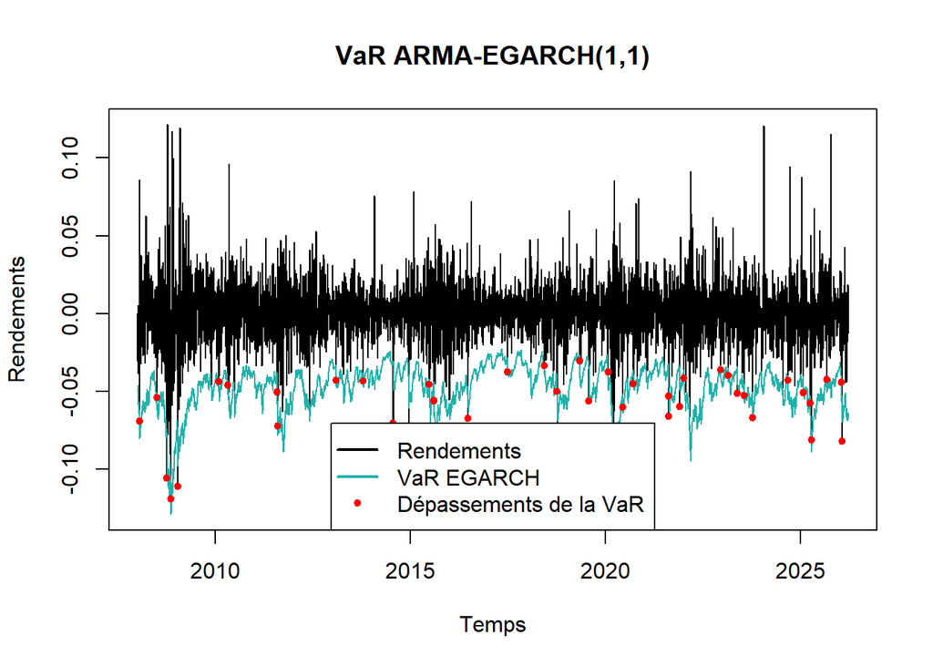

```r
VaR_EGARCH <- -(as.numeric(quantile(egarch11_fit, probs = t_couv)))

plot(
  as.zoo(cbind(rend_lvmh,-VaR_EGARCH)),
  screens=1,
  col = c("black","lightseagreen"),
  main="VaR ARMA-EGARCH(1,1)",
  xlab = "Temps",
  ylab = "Rendements"
)
points(as.zoo(rend_lvmh[as.numeric(rend_lvmh) < -VaR_EGARCH]), pch=20, col="red")
legend("bottom",c("Rendements","VaR EGARCH", "Dépassements de la VaR"),
         col = c("black","lightseagreen", 'red'),lty = c(1,1,NA),lwd = c(2,2,NA),pch = c(NA,NA,20))
```

```r
egarch11_estimation_fit <-
  rugarch::ugarchfit(
    egarch11_spec,
    rend_lvmh,
    out.sample = n_backtest
  )

forecast_egarch11 <-
  rugarch::ugarchforecast(
    egarch11_estimation_fit,
    data = rend_lvmh,
    n.roll = n_backtest-1,
    n.ahead = 1
  )

VaR_EGARCH_backtest <- -(as.numeric(quantile(forecast_egarch11, probs = 0.01)))

test_VaR_EGARCH<-
  rugarch::VaRTest(
    alpha = t_couv,
    actual = sample_backtest,
    VaR = -VaR_EGARCH_backtest,
    conf.level = 0.95
  )

tibble(
  name = names(unlist(test_VaR_EGARCH)),
  value = unlist(test_VaR_EGARCH)
) |>
  print(n = 20)
```

```
# A tibble: 12 × 2
   name            value
   <chr>           <chr>
 1 expected.exceed 20
 2 actual.exceed   33
 3 uc.H0           Correct Exceedances
 4 uc.LRstat       7.13670995390553
 5 uc.critical     3.84145882069412
 6 uc.LRp          0.00755215918452179
 7 uc.Decision     Reject H0
 8 cc.H0           Correct Exceedances & Independent
 9 cc.LRstat       7.48366413009826
10 cc.critical     5.99146454710798
11 cc.LRp          0.0237106239097272
12 cc.Decision     Reject H0
```

```r
HIT <- if_else(sample_backtest < -VaR_EGARCH_backtest, 1, 0)

HIT_centre <- HIT - 0.01

stats::Box.test(HIT_centre, lag = 5, type = "Ljung-Box")
```

```
    Box-Ljung test

data:  HIT_centre
X-squared = 2.3334, df = 5, p-value = 0.8013
```

```r
df <-
  tibble(
    HIT_centre = HIT_centre,
    rend = sample_backtest,
    rend2 = sample_backtest**2
  )

ARDL::ardl(
  HIT_centre ~ rend + rend2,
  data = df,
  order = 5
) |>
  summary()
```

```
Time series regression with "ts" data:
Start = 6, End = 2000

Call:
dynlm::dynlm(formula = full_formula, data = data, start = start,
    end = end)

Residuals:
     Min       1Q   Median       3Q      Max
-0.60796 -0.02566  0.00439  0.02278  0.85526

Coefficients:
                  Estimate Std. Error t value            Pr(>|t|)
(Intercept)      -0.006437   0.003062  -2.102              0.0357 *
L(HIT_centre, 1) -0.006197   0.022501  -0.275              0.7830
L(HIT_centre, 2) -0.023666   0.022487  -1.052              0.2927
L(HIT_centre, 3)  0.021837   0.022457   0.972              0.3310
L(HIT_centre, 4)  0.001126   0.022444   0.050              0.9600
L(HIT_centre, 5)  0.002927   0.022082   0.133              0.8946
rend             -2.744579   0.127168 -21.582 <0.0000000000000002 ***
L(rend, 1)       -0.006977   0.141556  -0.049              0.9607
L(rend, 2)       -0.147915   0.141509  -1.045              0.2960
L(rend, 3)        0.006971   0.141487   0.049              0.9607
L(rend, 4)        0.050008   0.142374   0.351              0.7254
L(rend, 5)        0.027816   0.142132   0.196              0.8449
rend2            64.778713   2.808041  23.069 <0.0000000000000002 ***
L(rend2, 1)      -1.501057   3.159775  -0.475              0.6348
L(rend2, 2)      -5.763421   3.135989  -1.838              0.0662 .
L(rend2, 3)      -8.022122   3.132233  -2.561              0.0105 *
L(rend2, 4)      -4.552022   3.144438  -1.448              0.1479
L(rend2, 5)      -6.167827   3.140954  -1.964              0.0497 *
---
Signif. codes:  0 '***' 0.001 '**' 0.01 '*' 0.05 '.' 0.1 ' ' 1

Residual standard error: 0.1041 on 1977 degrees of freedom
Multiple R-squared:  0.3195,    Adjusted R-squared:  0.3136
F-statistic:  54.6 on 17 and 1977 DF,  p-value: < 0.00000000000000022
```

```r
egarch22_spec <-
  rugarch::ugarchspec(
    variance.model =
      list(
        model = "eGARCH",
        garchOrder = c(2,2),
        variance.targeting = TRUE
      ),
    mean.model =
      list(
        armaOrder = c(ar,ma),
        include.mean = TRUE
      ),
    distribution.model = "sged"
  )

egarch22_fit <-
  rugarch::ugarchfit(
    egarch22_spec,
    rend_lvmh
  )

egarch22_fit
```

```
*---------------------------------*
*          GARCH Model Fit        *
*---------------------------------*

Conditional Variance Dynamics
-----------------------------------
GARCH Model : eGARCH(2,2)
Mean Model  : ARFIMA(2,0,2)
Distribution    : sged

Optimal Parameters
------------------------------------
        Estimate  Std. Error   t value Pr(>|t|)
mu      0.000167    0.000162    1.0291 0.303447
ar1     1.152746    0.040758   28.2827 0.000000
ar2    -0.635411    0.016933  -37.5249 0.000000
ma1    -1.168699    0.042580  -27.4473 0.000000
ma2     0.624857    0.016086   38.8449 0.000000
alpha1 -0.073890    0.011355   -6.5074 0.000000
alpha2 -0.083812    0.013088   -6.4038 0.000000
beta1   0.072347    0.000285  253.5093 0.000000
beta2   0.896708    0.000834 1075.3971 0.000000
gamma1  0.090615    0.017735    5.1094 0.000000
gamma2  0.069279    0.019834    3.4929 0.000478
skew    0.972383    0.016654   58.3868 0.000000
shape   1.277627    0.034443   37.0939 0.000000
omega  -0.246522          NA        NA       NA

Robust Standard Errors:
        Estimate  Std. Error   t value Pr(>|t|)
mu      0.000167    0.000166    1.0059  0.31445
ar1     1.152746    0.012892   89.4126  0.00000
ar2    -0.635411    0.005299 -119.9058  0.00000
ma1    -1.168699    0.014084  -82.9834  0.00000
ma2     0.624857    0.005764  108.4052  0.00000
alpha1 -0.073890    0.011680   -6.3260  0.00000
alpha2 -0.083812    0.012835   -6.5299  0.00000
beta1   0.072347    0.002370   30.5286  0.00000
beta2   0.896708    0.000993  903.4252  0.00000
gamma1  0.090615    0.016176    5.6017  0.00000
```

[output cut: 65 more lines]

```
Negative Sign Bias  0.8538 0.39324
Positive Sign Bias  2.2419 0.02501  **
Joint Effect        6.3993 0.09372   *


Adjusted Pearson Goodness-of-Fit Test:
------------------------------------
  group statistic p-value(g-1)
1    20     31.75      0.03330
2    30     41.07      0.06786
3    40     50.13      0.10910
4    50     61.28      0.11204


Elapsed time : 3.452638
```

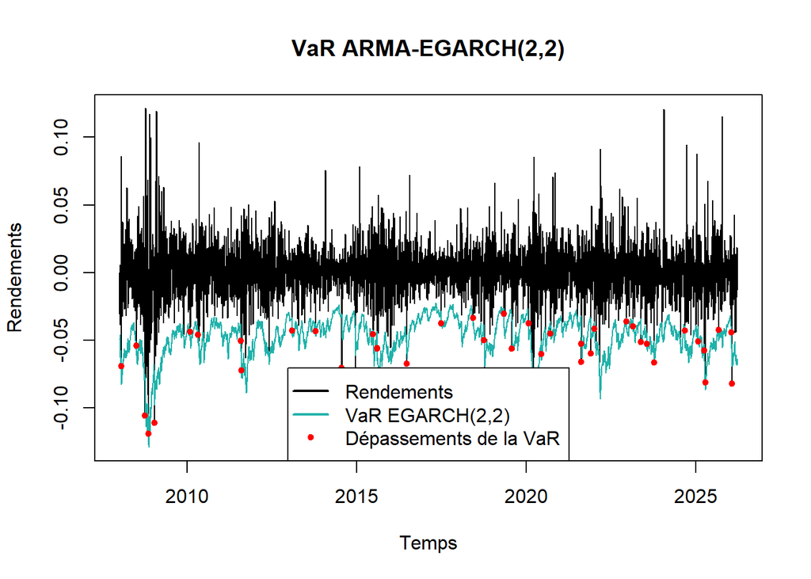

```r
VaR_EGARCH22 <- -(as.numeric(quantile(egarch22_fit, probs = t_couv)))

plot(
  as.zoo(cbind(rend_lvmh,-VaR_EGARCH22)),
  screens=1,
  col = c("black","lightseagreen"),
  main="VaR ARMA-EGARCH(2,2)",
  xlab = "Temps",
  ylab = "Rendements"
)
points(as.zoo(rend_lvmh[as.numeric(rend_lvmh) < -VaR_EGARCH22]), pch=20, col="red")
legend("bottom",c("Rendements","VaR EGARCH(2,2)", "Dépassements de la VaR"),
         col = c("black","lightseagreen", 'red'),lty = c(1,1,NA),lwd = c(2,2,NA),pch = c(NA,NA,20))
```

```r
egarch22_estimation_fit <-
  rugarch::ugarchfit(
    egarch22_spec,
    rend_lvmh,
    out.sample = n_backtest
  )

forecast_egarch22 <-
  rugarch::ugarchforecast(
    egarch22_estimation_fit,
    data = rend_lvmh,
    n.roll = n_backtest-1,
    n.ahead = 1
  )

VaR_EGARCH22_backtest <- -(as.numeric(quantile(forecast_egarch22, probs = 0.01)))

test_VaR_EGARCH22<-
  rugarch::VaRTest(
    alpha = t_couv,
    actual = sample_backtest,
    VaR = -VaR_EGARCH22_backtest,
    conf.level = 0.95
  )

tibble(
  name = names(unlist(test_VaR_EGARCH22)),
  value = unlist(test_VaR_EGARCH22)
) |>
  print(n = 20)
```

```
# A tibble: 12 × 2
   name            value
   <chr>           <chr>
 1 expected.exceed 20
 2 actual.exceed   33
 3 uc.H0           Correct Exceedances
 4 uc.LRstat       7.13670995390553
 5 uc.critical     3.84145882069412
 6 uc.LRp          0.00755215918452179
 7 uc.Decision     Reject H0
 8 cc.H0           Correct Exceedances & Independent
 9 cc.LRstat       13.0095513372679
10 cc.critical     5.99146454710798
11 cc.LRp          0.00149627638279803
12 cc.Decision     Reject H0
```

```r
HIT <- if_else(sample_backtest < -VaR_EGARCH22_backtest, 1, 0)

HIT_centre <- HIT - 0.01

stats::Box.test(HIT_centre, lag = 5, type = "Ljung-Box")
```

```
    Box-Ljung test

data:  HIT_centre
X-squared = 13.528, df = 5, p-value = 0.01891
```

```r
df <-
  tibble(
    HIT_centre = HIT_centre,
    rend = sample_backtest,
    rend2 = sample_backtest**2
  )

ARDL::ardl(
  HIT_centre ~ rend + rend2,
  data = df,
  order = 5
) |>
  summary()
```

```
Time series regression with "ts" data:
Start = 6, End = 2000

Call:
dynlm::dynlm(formula = full_formula, data = data, start = start,
    end = end)

Residuals:
     Min       1Q   Median       3Q      Max
-0.59603 -0.02628  0.00448  0.02283  0.85761

Coefficients:
                  Estimate Std. Error t value             Pr(>|t|)
(Intercept)      -0.006077   0.003072  -1.978              0.04807 *
L(HIT_centre, 1)  0.067740   0.022488   3.012              0.00263 **
L(HIT_centre, 2) -0.029915   0.022525  -1.328              0.18431
L(HIT_centre, 3)  0.021857   0.022492   0.972              0.33129
L(HIT_centre, 4) -0.002501   0.022498  -0.111              0.91148
L(HIT_centre, 5) -0.007926   0.022080  -0.359              0.71965
rend             -2.707467   0.127641 -21.212 < 0.0000000000000002 ***
L(rend, 1)        0.049106   0.141556   0.347              0.72870
L(rend, 2)       -0.103389   0.141398  -0.731              0.46475
L(rend, 3)       -0.059409   0.141305  -0.420              0.67422
L(rend, 4)        0.107224   0.142203   0.754              0.45093
L(rend, 5)       -0.048212   0.142094  -0.339              0.73442
rend2            63.585326   2.817451  22.568 < 0.0000000000000002 ***
L(rend2, 1)      -3.362464   3.154568  -1.066              0.28660
L(rend2, 2)      -5.519626   3.129885  -1.764              0.07797 .
L(rend2, 3)      -8.235362   3.125706  -2.635              0.00849 **
L(rend2, 4)      -4.508694   3.138587  -1.437              0.15101
L(rend2, 5)      -5.205354   3.136197  -1.660              0.09712 .
---
Signif. codes:  0 '***' 0.001 '**' 0.01 '*' 0.05 '.' 0.1 ' ' 1

Residual standard error: 0.1045 on 1977 degrees of freedom
Multiple R-squared:  0.3147,    Adjusted R-squared:  0.3088
F-statistic:  53.4 on 17 and 1977 DF,  p-value: < 0.00000000000000022
```

```r
df_VaR <-
  tibble(
    VaR_VCov = VaR_VCov,
    VaR_CFisher = VaR_CFisher,
    VaR_student = VaR_student,
    VaR_GARCH= VaR_GARCH,
    VaR_EGARCH = VaR_EGARCH,
    VaR_EGARCH22 = VaR_EGARCH22
  ) |>
  drop_na()

df_VaR_long <-
  df_VaR |>
  mutate(temps = row_number()) |>
  pivot_longer(
    cols = -temps,
    names_to = "model",
    values_to = "VaR"
  ) |>
  mutate(
    .by = temps,
    moyenne_VaR = mean(VaR)
  ) |>
  mutate(
    ecart = (VaR - moyenne_VaR) / moyenne_VaR
  ) |>
  summarize(
    .by = model,
    MRB = abs(mean(ecart))
  ) |>
  print()
```

```
# A tibble: 6 × 2
  model          MRB
  <chr>        <dbl>
1 VaR_VCov     0.251
2 VaR_CFisher  0.301
3 VaR_student  0.546
4 VaR_GARCH    0.204
5 VaR_EGARCH   0.196
6 VaR_EGARCH22 0.196
```